V The V Lab

# 医学与心理学中的 Meta 分析详解

从系统综述、效应量与异质性到森林图、敏感性分析和负责任报告

公共卫生学院学习模块

更新于 2026年08月12日

**适用对象**医学、心理学、公共卫生及循证研究学习者

**学习时长**约 180–240 分钟

**先修要求**效应量、置信区间、回归与基础 R

关于案例与软件 本教程的医学和心理学研究均为模拟的研究级汇总数据，不对应真实论文、患者或参与者。本页用 base R 展开核心计算，以便看清模型；正式综述应使用经过验证的专业软件，锁定版本与设置，并由另一分析者复核。

## 如何使用本教程

本教程沿着真实证据综合的顺序展开：

> **可回答的问题 → 预注册方案 → 系统检索与筛选 → 偏倚风险 → 可比效应量 → 合成模型 → 异质性 → 稳健性与缺失证据 → 确定性与报告**

代码展示的是统计合成部分；它不能代替系统检索、双人筛选、数据核对和偏倚评估。建议先通读概念，再分别完成医学和心理学案例，最后使用检查清单设计自己的分析。

### 学习目标

完成本教程后，你应能够：

- 区分系统综述、Meta 分析和叙述性综述；
- 用 PICO/PICOS 和目标估计量定义可合成的问题；
- 为二分类结局选择 RR、OR 或 RD，为连续结局选择 MD 或 Hedges’ $g$；
- 解释通用逆方差加权、共同效应模型与随机效应模型；
- 计算并解释 $Q$、$I^2$、$\tau^2$、平均效应 CI 和预测区间；
- 区分 DL、REML、Paule–Mandel 与 modified Knapp–Hartung 各自的作用；
- 构建并阅读森林图与漏斗图；
- 完成 leave-one-out、效应尺度和模型设定敏感性分析；
- 审慎使用亚组分析和 Meta 回归；
- 识别多结局、多时点、多臂和共享对照造成的依赖效应；
- 讨论发表偏倚、小研究效应、证据确定性和 PRISMA 报告要求；
- 为医学和心理学 Meta 分析写出不过度概括的结果段落。

# 1 Meta 分析在完整系统综述中的位置

## 1.1 三个概念不能互换

| 概念 | 核心任务 | 是否一定统计合成 |
| --- | --- | --- |
| 系统综述 | 按预设、透明、可复核的方法检索、筛选、评价并综合证据 | 否 |
| Meta 分析 | 在可辩护的共同问题和统计模型下定量合并研究结果 | 是 |
| 叙述性综述 | 以文字组织文献，方法透明度可有很大差异 | 否 |

一个 Meta 分析可以计算正确却回答错误的问题。例如，把不同疾病、不同干预版本、不同随访期或不同构念的量表合并，精确的平均数也可能没有清晰含义。反之，当临床或方法差异使合并不合理时，高质量系统综述可以不做 Meta 分析。

垃圾进，精确垃圾出 Meta 分析不会把有系统偏倚的研究“平均成无偏真相”。若偏倚方向相似，增加研究数可能让错误结论更精确。研究质量、可比性和缺失证据必须进入解释，而不是只在讨论最后列一句局限。

## 1.2 先定义每一次合成的 PICO 与 estimand

每一个 forest plot 背后都应有一个明确的 synthesis question：

- **P（Population）：**哪些患者或参与者、何种严重程度与场景？
- **I（Intervention/Exposure）：**干预成分、剂量、实施者和持续时间？
- **C（Comparator）：**安慰剂、常规照护、等待名单还是主动对照？
- **O（Outcome）：**定义、量表、方向和测量时间？
- **S（Study design）：**随机试验、队列、病例对照或其他设计？
- **Estimand：**ITT 还是符合方案；末次值还是变化值；RR、MD 或其他尺度？

医学示例的目标是：在 12 项模拟平行随机试验代表的一组可交换场景中，新预防方案相对标准管理对 30 天感染风险的**平均 RR**。心理学示例的目标是：在 14 项模拟 CBT 试验中，治疗结束时抑郁症状的**平均 Hedges’ $g$**；所有量表先统一为“分数越高症状越重”，所以负值有利于 CBT。

## 1.3 协议、检索、筛选和重复报告

在读取研究结果前，方案至少应固定：数据库和灰色文献来源、完整检索式、检索日期、语言和出版状态限制、双人筛选流程、冲突解决方式、主要结局与时间点、效应尺度、合成模型、零事件和缺失 SD 处理、亚组、敏感性分析及偏倚风险工具。

同一研究可能有注册记录、会议摘要、主要论文和多篇二次分析。Meta 分析的单位通常是**研究或独立比较**，不是 PDF 篇数；重复纳入同一参与者会人为提高精度。多篇报告应先链接为同一研究，再按预设规则抽取。

[PRISMA 2020](https://www.prisma-statement.org/prisma-2020) 是系统综述报告指南，不等于预注册。协议可根据主题注册于 PROSPERO、OSF 或其他适用平台；观察性流行病学 Meta 分析还可参考 MOOSE。

# 2 从原始汇总数据得到可比效应量

## 2.1 二分类结局：RR、OR 与 RD

令治疗组事件／非事件为 $a,b$，对照组为 $c,d$。风险比在对数尺度上计算：

$$y_i=\log(RR_i)=\log\left\{\frac{a/(a+b)}{c/(c+d)}\right\},\qquad
v_i=\frac1a-\frac1{a+b}+\frac1c-\frac1{c+d}.$$

优势比为 $OR=ad/(bc)$，风险差为 $RD=a/(a+b)-c/(c+d)$。三者回答不同问题：

| 尺度 | 零效应值 | 优点 | 限制 |
| --- | --- | --- | --- |
| RR | 1 | 队列与试验中较直观；常较稳定 | 仍需基线风险才能理解绝对影响 |
| OR | 1 | 病例对照研究可估；逻辑模型自然输出 | 结局常见时不能称为 RR |
| RD | 0 | 直接表达绝对风险变化 | 常随基线风险明显变化，跨研究异质性可能大 |

分析前必须统一事件方向。“感染”与“无感染”互换会把 RR 变成另一个非简单倒数的量；不能等看到哪个方向显著后再选择结局编码。

## 2.2 零事件不是统一加 0.5 就结束

单臂零事件使普通 log RR 或 log OR 无定义；两臂都零事件对这些相对尺度不提供直接信息。固定向四格加 0.5 可能在小样本、不平衡分配和罕见事件时引入偏差。应预设并比较适合问题的方法，如 Mantel–Haenszel、广义线性混合模型、beta-binomial 或其他罕见事件方法。

本教程函数不会静默修正：只要四格中任一格为零，就要求预设处理；只有明确设置 `correction = TRUE` 才对该研究四格加连续性校正，并标记双零事件研究。

```r
zero_demo <- data.frame(
  study = c("单臂零事件", "双臂零事件"),
  event_t = c(0, 0), total_t = c(50, 50),
  event_c = c(3, 0), total_c = c(50, 60)
)
zero_effect <- effect_log_rr(
  zero_demo$event_t, zero_demo$total_t,
  zero_demo$event_c, zero_demo$total_c,
  correction = TRUE
)
knitr::kable(
  cbind(zero_demo, zero_effect),
  digits = 3,
  caption = "显式 0.5 校正的教学示例；双零研究的 log RR 保留为缺失"
)
```

显式 0.5 校正的教学示例；双零研究的 log RR 保留为缺失

| study | event_t | total_t | event_c | total_c | yi | vi | se | corrected | double_zero |
| --- | --- | --- | --- | --- | --- | --- | --- | --- | --- |
| 单臂零事件 | 0 | 50 | 3 | 50 | -1.95 | 2.25 | 1.5 | TRUE | FALSE |
| 双臂零事件 | 0 | 50 | 0 | 60 | NA | NA | NA | TRUE | TRUE |

## 2.3 连续结局：MD 与标准化均值差

当研究使用同一量表和单位时，均值差最容易解释：

$$MD_i=\bar X_{Ti}-\bar X_{Ci},\qquad
v_i=\frac{s_{Ti}^2}{n_{Ti}}+\frac{s_{Ci}^2}{n_{Ci}}.$$

不同量表测量同一构念时，可用合并组内 SD 标准化：

$$s_p=\sqrt{\frac{(n_T-1)s_T^2+(n_C-1)s_C^2}{n_T+n_C-2}},\quad
d=\frac{\bar X_T-\bar X_C}{s_p},\quad g=J(df)d.$$

$J(df)$ 对小样本 Cohen’s $d$ 偏倚作校正。本教程使用一种常见的大样本方差近似；专业软件可能提供不同方差选项，方案中必须记录。

SMD 不是“万能临床单位”。它会受到研究内个体异质性、量表信度、纳入标准和 SD 计算方式影响。只有当量表确实测量相同构念时才应合并；不能仅因为都叫“心理健康评分”就放在一起。

心理学数据的方向审核 抽取表必须记录每个量表的高分含义和是否反向。若一项量表高分代表改善、另一项高分代表症状加重，应在合成前翻转其中一个效应方向。推荐在方案中规定“负值有利于干预”或相反方向，并由第二位分析者核对。

# 3 通用逆方差模型

## 3.1 每项研究贡献效应和方差

许多 Meta 分析可统一写成：每项研究提供效应估计 $y_i$ 及已知或估计的抽样方差 $v_i$。共同效应模型的权重为 $w_i=1/v_i$：

$$\hat\mu=\frac{\sum_i w_i y_i}{\sum_i w_i},\qquad
SE(\hat\mu)=\sqrt{\frac1{\sum_i w_i}}.$$

权重反映精度，不是研究质量分数。偏倚风险高的大型研究仍可能得到很大逆方差权重，因此偏倚风险不能通过简单乘一个主观“质量权重”解决。

## 3.2 共同效应与随机效应回答不同问题

| 模型 | 工作假设 | 汇总量的含义 |
| --- | --- | --- |
| 共同效应（传统 fixed-effect） | 所有研究估计同一个真实效应，差异来自抽样误差 | 该共同效应 |
| 随机效应 | 研究真实效应来自一个分布，观察差异来自真实变异与抽样误差 | 该分布的平均效应 |

随机效应权重为 $w_i^*=1/(v_i+\tau^2)$，其中 $\tau^2$ 是研究间真实效应方差。随机效应并没有“解决”异质性；它用一个分布模型描述未解释的变异。选择模型应依据问题与预期差异，而不是先做 $Q$ 检验再自动切换。

随机效应并非天然更保守 存在异质性时，随机效应相对提高小研究权重。若小研究因选择性发表或方法问题给出更大效应，随机效应平均值甚至可能离无效值更远。共同效应和随机效应都依赖研究可比性与偏倚假设。

## 3.3 $Q$、$I^2$、$H^2$ 与 $\tau^2$

- **Cochran $Q$：**观察到的加权差异与仅有抽样误差是否相容；少量研究时检出力低，很多研究时对微小差异敏感。
- **$I^2$：**$\max\{0,(Q-df)/Q\}\times100\%$，描述观察不一致中可归于研究间变异的相对比例，而非“有异质性的研究百分比”。
- **$H^2$：**这里使用传统的 $Q/df$；1 表示观察不一致与自由度相当，抽样中也可能小于 1。不同软件还可能报告与 $\tau^2$ 一致的其他定义，必须核对实现。
- **$\tau^2$：**模型所估计的真实效应方差；其单位是效应尺度的平方，RR/OR 时位于 log 尺度。

$I^2$ 会受研究精度影响：同样的 $\tau^2$ 在更精确研究中可能产生更高 $I^2$。应同时报告 $\tau^2$、预测区间、研究情境和 effect scale，而不是用固定的 25%／50%／75% 标签替代判断。

## 3.4 DL、REML 和 Paule–Mandel

- **DerSimonian–Laird（DL）：**矩估计，计算简单；研究少或异质性大时可能低估不确定性。
- **REML：**通过限制似然估计 $\tau^2$，通常有较好的统计性质，是常用默认之一。
- **Paule–Mandel（PM）：**令随机效应加权残差 $Q$ 接近自由度的矩方法，也常表现稳健。

$\tau^2$ 估计器与平均效应 CI 方法是两个不同选择。HKSJ／Knapp–Hartung 调整平均效应的不确定性，并不估计 $\tau^2$。

## 3.5 modified Knapp–Hartung 与预测区间

本教程随机效应平均值使用 modified Knapp–Hartung（mKH）：以 t 分布替代正态临界值，并把残差尺度因子限制为至少 1，避免 KH 方差估计小于未调整的模型方差。mKH 可能较保守，尤其研究很少时；方案应说明具体实现。

平均效应 CI 回答平均值位于何处。预测区间尝试描述一项与纳入研究可交换的新研究中**真实效应**可能位于何处：

$$\hat\mu\ \pm\ t_{k-2,0.975}\sqrt{\hat\tau^2+\widehat{Var}(\hat\mu)}.$$

本教程公式中的 $\widehat{Var}(\hat\mu)$ 使用 mKH 调整后的均值方差。这是 Riley／HTS 类常用近似之一，不是唯一标准。研究很少、效应分布非正态或漏斗图不对称时，预测区间可能不稳定；它也不是未来研究“观察到的估计值”区间。

# 4 医学案例：12 项二分类结局随机试验

## 4.1 问题、数据结构与效应方向

模拟问题是：与标准管理相比，新预防方案是否降低 30 天感染风险？每一行是一项独立平行 RCT，事件均定义为感染，因此 $RR<1$ 有利于新方案。

```r
stopifnot(
  !anyDuplicated(medical_data$study),
  all(medical_data$event_t <= medical_data$total_t),
  all(medical_data$event_c <= medical_data$total_c),
  all(medical_data$total_t > 0),
  all(medical_data$total_c > 0)
)

medical_display <- within(medical_data, {
  risk_t <- event_t / total_t
  risk_c <- event_c / total_c
})

knitr::kable(
  medical_display[c("study", "year", "event_t", "total_t", "event_c", "total_c",
                    "risk_t", "risk_c")],
  digits = 3,
  col.names = c("研究", "年份", "新方案事件", "新方案总数",
                "标准管理事件", "标准管理总数", "新方案风险", "标准管理风险"),
  caption = "模拟医学试验的 30 天感染数据"
)
```

模拟医学试验的 30 天感染数据

| 研究 | 年份 | 新方案事件 | 新方案总数 | 标准管理事件 | 标准管理总数 | 新方案风险 | 标准管理风险 |
| --- | --- | --- | --- | --- | --- | --- | --- |
| Med-01 | 2012 | 12 | 120 | 20 | 118 | 0.100 | 0.169 |
| Med-02 | 2013 | 14 | 90 | 15 | 92 | 0.156 | 0.163 |
| Med-03 | 2014 | 10 | 180 | 30 | 175 | 0.056 | 0.171 |
| Med-04 | 2015 | 31 | 240 | 29 | 238 | 0.129 | 0.122 |
| Med-05 | 2016 | 20 | 150 | 25 | 148 | 0.133 | 0.169 |
| Med-06 | 2017 | 27 | 320 | 43 | 315 | 0.084 | 0.137 |
| Med-07 | 2018 | 9 | 110 | 16 | 112 | 0.082 | 0.143 |
| Med-08 | 2019 | 29 | 210 | 24 | 205 | 0.138 | 0.117 |
| Med-09 | 2020 | 31 | 400 | 48 | 395 | 0.078 | 0.122 |
| Med-10 | 2021 | 11 | 170 | 25 | 168 | 0.065 | 0.149 |
| Med-11 | 2022 | 20 | 130 | 19 | 132 | 0.154 | 0.144 |
| Med-12 | 2024 | 28 | 260 | 40 | 255 | 0.108 | 0.157 |

这些只是教学数据。真实抽取还应记录随机化单位、结局定义、失访、ITT 分母、聚类或多臂结构、调整估计、偏倚风险和资金来源。

## 4.2 计算每项研究的 log RR

```r
medical_es <- effect_log_rr(
  medical_data$event_t, medical_data$total_t,
  medical_data$event_c, medical_data$total_c
)
medical_meta <- cbind(medical_data, medical_es)
medical_meta$rr <- exp(medical_meta$yi)
medical_meta$rr_lower <- exp(medical_meta$yi - qnorm(0.975) * medical_meta$se)
medical_meta$rr_upper <- exp(medical_meta$yi + qnorm(0.975) * medical_meta$se)

knitr::kable(
  medical_meta[c("study", "rr", "rr_lower", "rr_upper", "se")],
  digits = 3,
  col.names = c("研究", "RR", "95% CI 下限", "95% CI 上限", "log RR 的 SE"),
  caption = "各项医学试验的风险比"
)
```

各项医学试验的风险比

| 研究 | RR | 95% CI 下限 | 95% CI 上限 | log RR 的 SE |
| --- | --- | --- | --- | --- |
| Med-01 | 0.590 | 0.302 | 1.152 | 0.341 |
| Med-02 | 0.954 | 0.489 | 1.861 | 0.341 |
| Med-03 | 0.324 | 0.163 | 0.643 | 0.349 |
| Med-04 | 1.060 | 0.660 | 1.702 | 0.242 |
| Med-05 | 0.789 | 0.459 | 1.358 | 0.277 |
| Med-06 | 0.618 | 0.392 | 0.975 | 0.232 |
| Med-07 | 0.573 | 0.264 | 1.241 | 0.394 |
| Med-08 | 1.180 | 0.712 | 1.955 | 0.258 |
| Med-09 | 0.638 | 0.415 | 0.980 | 0.219 |
| Med-10 | 0.435 | 0.221 | 0.855 | 0.345 |
| Med-11 | 1.069 | 0.599 | 1.908 | 0.296 |
| Med-12 | 0.687 | 0.437 | 1.078 | 0.230 |

每项区间表达该研究的抽样不确定性。小研究区间通常更宽，但较大样本不保证偏倚更小。

## 4.3 共同效应与随机效应结果

```r
medical_common <- fit_meta(medical_meta$yi, medical_meta$vi, method = "common")
medical_dl <- fit_meta(medical_meta$yi, medical_meta$vi, method = "DL")
medical_pm <- fit_meta(medical_meta$yi, medical_meta$vi, method = "PM")
medical_reml <- fit_meta(medical_meta$yi, medical_meta$vi, method = "REML")

fit_row_ratio <- function(fit, label) {
  data.frame(
    模型 = label,
    RR = exp(fit$estimate),
    CI下限 = exp(fit$lower),
    CI上限 = exp(fit$upper),
    PI下限 = if (is.finite(fit$pred_lower)) exp(fit$pred_lower) else NA_real_,
    PI上限 = if (is.finite(fit$pred_upper)) exp(fit$pred_upper) else NA_real_,
    tau平方 = fit$tau2,
    check.names = FALSE
  )
}

medical_model_table <- rbind(
  fit_row_ratio(medical_common, "共同效应 + Wald"),
  fit_row_ratio(medical_dl, "随机效应 DL + mKH"),
  fit_row_ratio(medical_pm, "随机效应 PM + mKH"),
  fit_row_ratio(medical_reml, "随机效应 REML + mKH")
)

knitr::kable(
  medical_model_table,
  digits = 3,
  caption = "医学案例在不同模型与研究间方差估计器下的汇总"
)
```

医学案例在不同模型与研究间方差估计器下的汇总

| 模型 | RR | CI下限 | CI上限 | PI下限 | PI上限 | tau平方 |
| --- | --- | --- | --- | --- | --- | --- |
| 共同效应 + Wald | 0.729 | 0.623 | 0.854 | NA | NA | 0.000 |
| 随机效应 DL + mKH | 0.720 | 0.571 | 0.909 | 0.421 | 1.23 | 0.047 |
| 随机效应 PM + mKH | 0.720 | 0.570 | 0.909 | 0.409 | 1.27 | 0.053 |
| 随机效应 REML + mKH | 0.721 | 0.572 | 0.910 | 0.429 | 1.21 | 0.043 |

REML 随机效应平均 RR 约为 0.72，mKH 95% CI 为 0.57 至 0.91。这表示在模型所代表的可交换场景中，平均相对风险较低；它不是“每个医院都会降低相同比例”的承诺。

## 4.4 异质性与预测区间

```r
medical_heterogeneity <- data.frame(
  指标 = c("Cochran Q", "Q 自由度", "Q 检验 p 值", "I-squared (%)",
           "H-squared", "REML tau-squared", "REML tau"),
  数值 = c(
    medical_reml$Q, medical_reml$Q_df, medical_reml$Q_p,
    medical_reml$I2, medical_reml$H2,
    medical_reml$tau2, sqrt(medical_reml$tau2)
  )
)
knitr::kable(
  medical_heterogeneity,
  digits = 3,
  caption = "医学案例的异质性统计量（tau 位于 log RR 尺度）"
)
```

医学案例的异质性统计量（tau 位于 log RR 尺度）

| 指标 | 数值 |
| --- | --- |
| Cochran Q | 17.595 |
| Q 自由度 | 11.000 |
| Q 检验 p 值 | 0.091 |
| I-squared (%) | 37.481 |
| H-squared | 1.600 |
| REML tau-squared | 0.043 |
| REML tau | 0.208 |

$I^2$ 约为 37.5%，但不应只贴“中等异质性”标签。更直接的信息是 REML 95% 预测区间：RR 0.43 至 1.21，跨过 1。平均效应与 1 不相容，并不保证相似新场景的真实效应一定有利。

**平均 CI 与预测区间并不矛盾：**前者量化平均 log RR 的估计精度；后者把研究间真实变异也纳入，回答潜在新场景可能有多不同。

## 4.5 森林图

```r
forest_meta(
  medical_meta$yi,
  medical_meta$vi,
  labels = paste(medical_meta$study, medical_meta$year),
  fit = medical_reml,
  ratio = TRUE,
  xlab = "风险比 RR（对数间距）",
  pooled_label = "REML 平均 RR",
  prediction_label = "95% 预测区间"
)
```

[figure not shown]

模拟医学试验在 log 坐标上绘制的 RR 森林图。方块大小反映随机效应权重；菱形为 REML 平均效应，红线为预测区间。横轴标签显示 RR。

森林图先用于检查方向、精度、离群结果和可见异质性，再读汇总菱形。方块大小不是样本量本身，也不是研究质量评级。

## 4.6 从相对效应回到绝对尺度

RR 的实际意义取决于基线风险。下面把平均 RR 应用于纳入试验对照组风险的中位数，只作为一种场景转换：

```r
reference_risk <- median(medical_meta$event_c / medical_meta$total_c)
pooled_rr <- exp(medical_reml$estimate)
treated_risk <- reference_risk * pooled_rr
illustrative_rd <- treated_risk - reference_risk

absolute_translation <- data.frame(
  对照参考风险 = reference_risk,
  应用平均RR后的风险 = treated_risk,
  每1000人的风险差 = 1000 * illustrative_rd,
  check.names = FALSE
)
knitr::kable(
  absolute_translation,
  digits = 3,
  caption = "把平均 RR 转换到一个教学性参考风险"
)
```

把平均 RR 转换到一个教学性参考风险

| 对照参考风险 | 应用平均RR后的风险 | 每1000人的风险差 |
| --- | --- | --- |
| 0.146 | 0.106 | -40.8 |

这不是直接合并 RD，也没有传播参考风险、RR 和异质性的全部不确定性。正式决策应使用目标人群的可信基线风险，并展示多个合理场景。

## 4.7 模型与 leave-one-out 敏感性分析

DL、PM 和 REML 的差异提醒我们：研究数有限时，$\tau^2$ 不是已知常数。还应逐项排除研究并**重新估计** $\tau^2$：

```r
medical_loo <- leave_one_out(
  medical_meta$yi, medical_meta$vi,
  labels = medical_meta$study,
  method = "REML"
)
medical_loo$rr <- exp(medical_loo$estimate)
medical_loo$rr_lower <- exp(medical_loo$lower)
medical_loo$rr_upper <- exp(medical_loo$upper)

knitr::kable(
  medical_loo[c("omitted", "rr", "rr_lower", "rr_upper", "tau2", "I2")],
  digits = 3,
  col.names = c("排除研究", "平均 RR", "CI 下限", "CI 上限", "tau-squared", "I-squared (%)"),
  caption = "医学案例的 leave-one-out REML 分析"
)
```

医学案例的 leave-one-out REML 分析

| 排除研究 | 平均 RR | CI 下限 | CI 上限 | tau-squared | I-squared (%) |
| --- | --- | --- | --- | --- | --- |
| Med-01 | 0.730 | 0.567 | 0.941 | 0.051 | 41.8 |
| Med-02 | 0.706 | 0.550 | 0.907 | 0.050 | 41.0 |
| Med-03 | 0.763 | 0.623 | 0.934 | 0.014 | 16.0 |
| Med-04 | 0.691 | 0.544 | 0.879 | 0.034 | 32.9 |
| Med-05 | 0.713 | 0.550 | 0.923 | 0.058 | 42.9 |
| Med-06 | 0.732 | 0.565 | 0.949 | 0.055 | 41.2 |
| Med-07 | 0.730 | 0.567 | 0.938 | 0.049 | 41.9 |
| Med-08 | 0.688 | 0.548 | 0.864 | 0.022 | 27.3 |
| Med-09 | 0.730 | 0.562 | 0.948 | 0.058 | 41.7 |
| Med-10 | 0.747 | 0.591 | 0.945 | 0.035 | 34.3 |
| Med-11 | 0.697 | 0.547 | 0.889 | 0.042 | 36.7 |
| Med-12 | 0.723 | 0.556 | 0.939 | 0.061 | 42.9 |

影响性分析是诊断工具，不是删研究算法。若某研究改变结论，应核查人群、设计、数据和偏倚风险，并报告含与不含它的结果；仅因它“让结果不显著”而删除属于结果驱动分析。

# 5 心理学案例：不同抑郁量表的 14 项 CBT 试验

## 5.1 为什么使用 Hedges’ $g$

模拟研究使用 PHQ-9、BDI-II、HADS-D 和 CES-D。它们的单位和范围不同，因此全部 14 项研究不能用原始 MD 合并。我们假设这些量表在此问题中足够接近地测量同一抑郁症状构念，并已统一为高分更差；负 $g$ 有利于 CBT。

```r
stopifnot(
  !anyDuplicated(psychology_data$study),
  all(psychology_data$n_t > 1), all(psychology_data$n_c > 1),
  all(psychology_data$sd_t > 0), all(psychology_data$sd_c > 0)
)

knitr::kable(
  psychology_data,
  digits = 2,
  col.names = c("研究", "量表", "CBT n", "CBT 均值", "CBT SD",
                "对照 n", "对照均值", "对照 SD", "治疗节数", "形式"),
  caption = "模拟心理学试验的治疗结束时抑郁量表数据"
)
```

模拟心理学试验的治疗结束时抑郁量表数据

| 研究 | 量表 | CBT n | CBT 均值 | CBT SD | 对照 n | 对照均值 | 对照 SD | 治疗节数 | 形式 |
| --- | --- | --- | --- | --- | --- | --- | --- | --- | --- |
| Psy-01 | PHQ-9 | 70 | 11.5 | 5.1 | 68 | 14.5 | 5.0 | 10 | Individual |
| Psy-02 | BDI-II | 55 | 25.4 | 8.2 | 57 | 27.0 | 8.0 | 6 | Group |
| Psy-03 | HADS-D | 90 | 10.4 | 4.0 | 88 | 12.0 | 4.2 | 8 | Individual |
| Psy-04 | CES-D | 120 | 25.5 | 9.5 | 118 | 25.0 | 9.2 | 4 | Group |
| Psy-05 | PHQ-9 | 48 | 11.0 | 4.8 | 50 | 15.0 | 5.1 | 8 | Individual |
| Psy-06 | BDI-II | 75 | 23.7 | 7.7 | 74 | 26.0 | 7.9 | 10 | Group |
| Psy-07 | HADS-D | 130 | 9.5 | 3.8 | 128 | 11.5 | 4.0 | 6 | Individual |
| Psy-08 | CES-D | 62 | 27.0 | 10.2 | 65 | 28.0 | 9.8 | 4 | Group |
| Psy-09 | PHQ-9 | 85 | 10.4 | 5.3 | 82 | 14.0 | 5.0 | 12 | Individual |
| Psy-10 | BDI-II | 110 | 22.5 | 8.0 | 108 | 24.5 | 8.3 | 6 | Group |
| Psy-11 | HADS-D | 58 | 10.7 | 4.1 | 60 | 12.5 | 4.0 | 8 | Individual |
| Psy-12 | CES-D | 140 | 27.9 | 9.4 | 136 | 27.0 | 9.6 | 10 | Group |
| Psy-13 | PHQ-9 | 95 | 12.7 | 4.9 | 92 | 15.5 | 5.2 | 10 | Individual |
| Psy-14 | BDI-II | 72 | 22.7 | 7.9 | 70 | 25.5 | 8.1 | 8 | Group |

真实综述还必须确认诊断标准、对照类型、治疗师训练、盲法可行性、依从性、量表版本和随访时点。等待名单与主动心理对照通常不能无条件视为同一 comparator。

## 5.2 计算 Hedges’ $g$ 并合成

```r
psych_es <- effect_hedges_g(
  psychology_data$n_t, psychology_data$mean_t, psychology_data$sd_t,
  psychology_data$n_c, psychology_data$mean_c, psychology_data$sd_c
)
psych_meta <- cbind(psychology_data, psych_es)
psych_meta$g_lower <- psych_meta$yi - qnorm(0.975) * psych_meta$se
psych_meta$g_upper <- psych_meta$yi + qnorm(0.975) * psych_meta$se

psych_reml <- fit_meta(psych_meta$yi, psych_meta$vi, method = "REML")
psych_common <- fit_meta(psych_meta$yi, psych_meta$vi, method = "common")

knitr::kable(
  psych_meta[c("study", "scale", "yi", "g_lower", "g_upper")],
  digits = 3,
  col.names = c("研究", "量表", "Hedges g", "95% CI 下限", "95% CI 上限"),
  caption = "每项心理学试验的标准化均值差"
)
```

每项心理学试验的标准化均值差

| 研究 | 量表 | Hedges g | 95% CI 下限 | 95% CI 上限 |
| --- | --- | --- | --- | --- |
| Psy-01 | PHQ-9 | -0.591 | -0.932 | -0.250 |
| Psy-02 | BDI-II | -0.196 | -0.568 | 0.175 |
| Psy-03 | HADS-D | -0.389 | -0.685 | -0.092 |
| Psy-04 | CES-D | 0.053 | -0.201 | 0.307 |
| Psy-05 | PHQ-9 | -0.801 | -1.212 | -0.389 |
| Psy-06 | BDI-II | -0.293 | -0.616 | 0.029 |
| Psy-07 | HADS-D | -0.511 | -0.759 | -0.263 |
| Psy-08 | CES-D | -0.099 | -0.448 | 0.249 |
| Psy-09 | PHQ-9 | -0.695 | -1.008 | -0.383 |
| Psy-10 | BDI-II | -0.245 | -0.511 | 0.022 |
| Psy-11 | HADS-D | -0.442 | -0.807 | -0.076 |
| Psy-12 | CES-D | 0.094 | -0.142 | 0.331 |
| Psy-13 | PHQ-9 | -0.552 | -0.844 | -0.260 |
| Psy-14 | BDI-II | -0.348 | -0.680 | -0.017 |

```r
psych_results <- rbind(
  data.frame(
    模型 = "共同效应 + Wald", g = psych_common$estimate,
    CI下限 = psych_common$lower, CI上限 = psych_common$upper,
    PI下限 = NA, PI上限 = NA, tau平方 = 0
  ),
  data.frame(
    模型 = "随机效应 REML + mKH", g = psych_reml$estimate,
    CI下限 = psych_reml$lower, CI上限 = psych_reml$upper,
    PI下限 = psych_reml$pred_lower, PI上限 = psych_reml$pred_upper,
    tau平方 = psych_reml$tau2
  )
)

knitr::kable(
  psych_results,
  digits = 3,
  caption = "心理学案例的共同效应与随机效应结果"
)
```

心理学案例的共同效应与随机效应结果

| 模型 | g | CI下限 | CI上限 | PI下限 | PI上限 | tau平方 |
| --- | --- | --- | --- | --- | --- | --- |
| 共同效应 + Wald | -0.317 | -0.398 | -0.236 | NA | NA | 0.000 |
| 随机效应 REML + mKH | -0.345 | -0.501 | -0.188 | -0.848 | 0.158 | 0.048 |

随机效应平均 $g$ 为 -0.34（mKH 95% CI -0.50 至 -0.19）。负方向平均有利于 CBT，但这不是 PHQ-9 分数下降多少分，也不应仅按 0.2／0.5／0.8 的固定经验阈值决定临床意义。

## 5.3 心理学异质性和预测区间

```r
psych_heterogeneity <- data.frame(
  Q = psych_reml$Q,
  Q_df = psych_reml$Q_df,
  Q_p = psych_reml$Q_p,
  I2_percent = psych_reml$I2,
  tau2 = psych_reml$tau2,
  tau = sqrt(psych_reml$tau2),
  prediction_lower = psych_reml$pred_lower,
  prediction_upper = psych_reml$pred_upper,
  check.names = FALSE
)
knitr::kable(
  psych_heterogeneity,
  digits = 3,
  col.names = c("Q", "df", "Q p 值", "I-squared (%)", "tau-squared",
                "tau", "PI 下限", "PI 上限"),
  caption = "心理学案例的异质性与预测区间"
)
```

心理学案例的异质性与预测区间

| Q | df | Q p 值 | I-squared (%) | tau-squared | tau | PI 下限 | PI 上限 |
| --- | --- | --- | --- | --- | --- | --- | --- |
| 41 | 13 | 0 | 68.3 | 0.048 | 0.219 | -0.848 | 0.158 |

预测区间约为 -0.85 至 0.16，跨过 0。即使平均效应的 CI 未跨 0，某些相似场景的真实效应仍可能接近无效或方向不同。可能原因包括对照强度、治疗形式、样本严重程度、量表、治疗师和偏倚风险，但本数据不能自动识别原因。

```r
forest_meta(
  psych_meta$yi,
  psych_meta$vi,
  labels = paste(psych_meta$study, psych_meta$scale),
  fit = psych_reml,
  ratio = FALSE,
  xlab = "Hedges' g（负值有利于 CBT）",
  pooled_label = "REML 平均 g",
  prediction_label = "95% 预测区间"
)
```

[figure not shown]

模拟心理学 CBT 试验的 Hedges’ g 森林图。负值有利于 CBT；菱形为 REML 平均效应，红线为预测区间。

## 5.4 同一量表时优先保留原始单位

四项 PHQ-9 研究可以用 MD 合成，因为量表和方向一致：

```r
phq <- subset(psychology_data, scale == "PHQ-9")
phq_es <- effect_md(phq$n_t, phq$mean_t, phq$sd_t,
                    phq$n_c, phq$mean_c, phq$sd_c)
phq_fit <- fit_meta(phq_es$yi, phq_es$vi, method = "REML")

data.frame(
  研究数 = phq_fit$k,
  平均MD = phq_fit$estimate,
  CI下限 = phq_fit$lower,
  CI上限 = phq_fit$upper,
  tau平方 = phq_fit$tau2,
  check.names = FALSE
) |>
  knitr::kable(
    digits = 3,
    caption = "仅 PHQ-9 研究的随机效应均值差（CBT − 对照，单位为 PHQ-9 分）"
  )
```

仅 PHQ-9 研究的随机效应均值差（CBT − 对照，单位为 PHQ-9 分）

| 研究数 | 平均MD | CI下限 | CI上限 | tau平方 |
| --- | --- | --- | --- | --- |
| 4 | -3.27 | -4.6 | -1.95 | 0 |

MD 更接近临床解释，但这里只代表 PHQ-9 子集。不能把它与全部量表的 $g$ 当成同一 estimand；也不应把治疗后分数 SMD 与变化分数 SMD 随意混合，除非预设的方法和相关性假设支持。

# 6 探索异质性：亚组与 Meta 回归

## 6.1 亚组差异必须直接检验

下面比较个体 CBT 与团体 CBT。先分别汇总只是描述；亚组差异应通过包含组别指示变量的 Meta 回归直接检验，而不是比较“一组显著、另一组不显著”。

```r
format_levels <- levels(psych_meta$format)
psych_subgroup <- do.call(rbind, lapply(format_levels, function(level) {
  take <- psych_meta$format == level
  fit <- fit_meta(psych_meta$yi[take], psych_meta$vi[take], method = "REML")
  data.frame(
    形式 = level, 研究数 = sum(take), 平均g = fit$estimate,
    CI下限 = fit$lower, CI上限 = fit$upper, tau平方 = fit$tau2
  )
}))

format_dummy <- as.numeric(psych_meta$format == "Individual")
X_format <- cbind(`(Intercept)` = 1, Individual_vs_Group = format_dummy)
format_model <- fit_meta(
  psych_meta$yi, psych_meta$vi,
  method = "REML", X = X_format
)

knitr::kable(psych_subgroup, digits = 3, caption = "按 CBT 形式分层的描述性合成")
```

按 CBT 形式分层的描述性合成

| 形式 | 研究数 | 平均g | CI下限 | CI上限 | tau平方 |
| --- | --- | --- | --- | --- | --- |
| Group | 7 | -0.126 | -0.301 | 0.049 | 0.013 |
| Individual | 7 | -0.551 | -0.698 | -0.403 | 0.000 |

```r
knitr::kable(
  format_model$coefficients,
  digits = 3,
  caption = "以 Group 为参照的随机效应 Meta 回归"
)
```

以 Group 为参照的随机效应 Meta 回归

| term | estimate | se | lower | upper | statistic | p |
| --- | --- | --- | --- | --- | --- | --- |
| (Intercept) | -0.118 | 0.062 | -0.252 | 0.016 | -1.92 | 0.079 |
| Individual_vs_Group | -0.435 | 0.089 | -0.630 | -0.240 | -4.86 | 0.000 |

这里 `Individual_vs_Group` 系数及其 p 值就是两个亚组平均效应差异的直接检验。若 moderator 有三个或更多水平，应使用全部虚拟变量的 omnibus F／Wald 检验，而不能挑一个系数。该研究层比较即使很精确，也可能被人群、对照强度、治疗节数或偏倚风险混杂，不能解释为把同一患者从团体 CBT 改为个体 CBT 的因果效应。

## 6.2 连续 moderator：治疗节数

```r
sessions_centered <- psych_meta$sessions - mean(psych_meta$sessions)
X_sessions <- cbind(`(Intercept)` = 1, sessions_centered = sessions_centered)
sessions_model <- fit_meta(
  psych_meta$yi, psych_meta$vi,
  method = "REML", X = X_sessions
)

knitr::kable(
  sessions_model$coefficients,
  digits = 3,
  caption = "治疗节数的探索性随机效应 Meta 回归"
)
```

治疗节数的探索性随机效应 Meta 回归

| term | estimate | se | lower | upper | statistic | p |
| --- | --- | --- | --- | --- | --- | --- |
| (Intercept) | -0.344 | 0.068 | -0.493 | -0.195 | -5.04 | 0.000 |
| sessions_centered | -0.051 | 0.029 | -0.114 | 0.012 | -1.75 | 0.105 |

斜率描述研究层面每多一节治疗与平均 $g$ 的关联，并不是个体剂量反应。14 项研究只支持非常有限的 moderator 探索；“每个系数至少约 10 项研究”至多是警示下限，不是充分保证。多重尝试 moderator 会制造偶然发现。

# 7 小研究效应与缺失证据

## 7.1 漏斗图能提示什么

漏斗图绘制效应估计与标准误。若只有抽样误差、模型适当且没有大小相关效应，较精确研究通常聚集在顶部，较小研究在底部更分散。

```r
funnel_meta(
  psych_meta$yi,
  psych_meta$vi,
  fit = psych_reml,
  xlab = "Hedges' g"
)
```

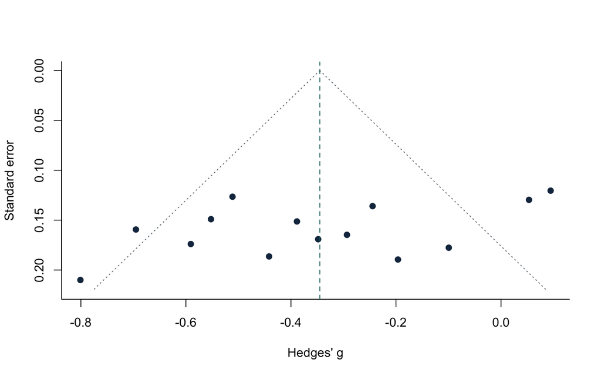

模拟心理学试验的漏斗图。虚线为 REML 平均效应及其 95% 伪界限；不对称不等同于发表偏倚。

漏斗图不对称可能来自发表或选择性报告，也可能来自真实异质性、小研究实施质量、效应尺度与基线风险关系、异常研究或偶然性。对称也不能证明没有缺失结果。

## 7.2 Egger 回归只是一个诊断

```r
psych_egger <- egger_test(psych_meta$yi, psych_meta$vi)
knitr::kable(
  psych_egger,
  digits = 3,
  caption = "心理学案例的 Egger 回归截距检验"
)
```

心理学案例的 Egger 回归截距检验

| intercept | se | t | df | p |
| --- | --- | --- | --- | --- |
| -5.26 | 2.69 | -1.95 | 12 | 0.075 |

Egger 检验通常不应在少于约 10 项独立研究时被强调；即使研究更多，它也是小研究效应检验，不是“发表偏倚检验”。存在异质性时其解释更复杂。Trim-and-fill 也不是找回真实缺失研究的可靠修复，应至多作为强假设下的敏感性分析。

## 7.3 缺失证据需要从研究过程评估

更有信息的做法包括：检索注册平台和方案；比较计划与报告结局；联系作者；纳入灰色文献；核对时间点；检查结果是否因显著性而选择；在合理选择机制下做敏感性分析。不能只靠一个漏斗图决定证据是否可信。

# 8 依赖效应与复杂研究结构

## 8.1 为什么“效应行数”不等于独立研究数

心理学研究常报告多个量表、多个随访、多个干预组和多个亚组。医学试验可能共享一个对照组。把这些相关效应当成独立研究会重复计算参与者并低估标准误。

| 结构 | 相关性来源 | 合理方向 |
| --- | --- | --- |
| 同一研究多个结局 | 同一参与者完成多个量表 | 预设一个主要结局；或多变量／多层 Meta 分析 |
| 多个时间点 | 同一参与者重复测量 | 预设主要时间点；或显式建模时间内相关性 |
| 多臂试验共享对照 | 对照参与者被用于多个比较 | 合并相关干预臂、拆分对照或使用多变量方法 |
| 聚类随机试验 | 同一集群内参与者相关 | 使用已校正的效应／SE，或按 ICC 调整有效样本量 |
| 同一队列多篇论文 | 参与者重复 | 链接报告，按研究 ID 去重 |

正式分析可使用多变量或多层 Meta 分析，或按研究聚类并带小样本修正的稳健方差估计。当前项目不安装相应扩展包，因此本页不以错误的独立性近似演示这些复杂模型。

## 8.2 观察性研究的调整估计

观察性医学研究常报告不同协变量集的 OR、HR 或 RR。合并前应预设优先调整集，并确认每项估计回答近似相同的条件或因果问题。把粗估计和过度调整估计混合，会产生难以解释的平均量；残余混杂不会被 Meta 分析消除。

# 9 风险偏倚、敏感性分析与证据确定性

## 9.1 偏倚风险不是总分

随机试验可按随机化过程、偏离干预、缺失结局、结局测量和选择性报告等领域评价；观察性研究还需深入考虑混杂和选择。简单把多个领域相加成“质量分数”会隐藏致命问题，且不适合作为机械逆方差修正。

建议把偏倚判断用于：解释方向与大小；预设排除高风险研究的敏感性分析；比较低风险证据；解释异质性；评价证据确定性。排除规则必须在看汇总结果前确定。

## 9.2 一套最小敏感性分析矩阵

| 决策 | 主分析 | 合理敏感性分析 |
| --- | --- | --- |
| 合成模型 | REML + mKH | 共同效应；PM／DL；专业软件的其他稳健方法 |
| 效应尺度 | 医学 RR；心理学 $g$ | RD／OR；同量表 MD；方向核查 |
| 零事件 | 预设罕见事件方法 | 连续性校正规则、双零研究处理 |
| 偏倚风险 | 全部合格研究 | 排除预设关键领域高风险研究 |
| 影响研究 | 全部研究 | leave-one-out；核查后有依据的情景分析 |
| 缺失 SD／相关性 | 预设推算值 | 多个合理相关系数或 SD 假设 |
| 依赖效应 | 预设单一结局／时间 | 多变量、分层或研究聚类稳健方法 |

敏感性分析应回答结论对哪些可辩护决策敏感，而不是寻找最小 p 值。

## 9.3 证据确定性

统计精度只是确定性的一部分。还需考虑偏倚风险、不一致性、间接性、不精确性和发表偏倚等领域。大样本、窄 CI 的 Meta 分析若来自间接或高偏倚研究，仍可能低确定性。GRADE 等框架需要领域判断，不能从 $I^2$ 或 p 值自动生成。

# 10 结果报告与可复现工作流

## 10.1 预注册分析清单

在提取结果前写明：

- 每次 synthesis 的 PICO/PICOS、目标总体和 estimand；
- 主要结局、量表方向、时间点和效应尺度；
- 多篇报告去重、多个量表／时间点／干预臂选择规则；
- 使用调整还是未调整估计以及调整集优先级；
- 共同效应或随机效应目标及选择理由；
- $\tau^2$ 估计器、平均效应 CI 方法和预测区间约定；
- 零事件、缺失 SD、变化分数、聚类和 crossover 的处理；
- 亚组、moderator、交互检验和多重性方案；
- 偏倚风险、敏感性分析、缺失证据和证据确定性方法；
- 软件、包版本、函数设置、随机种子和独立复核流程。

## 10.2 医学案例报告模板

> 纳入 12 项模拟平行随机试验，共 4733 名参与者。以感染为事件，REML 随机效应模型及 modified Knapp–Hartung 推断得到平均 RR 0.72（95% CI 0.57–0.91）。研究间方差 $\tau^2=0.043$（log RR 尺度），$I^2=37.5\%$；95% 预测区间为 0.43–1.21。平均结果提示相对风险降低，但预测区间跨过 1，故效应不应被假定为在所有相似场景中方向一致。所有数据为模拟结果，未进行真实偏倚风险或证据确定性评估。

## 10.3 心理学案例报告模板

> 纳入 14 项模拟 CBT 试验，共 2406 名参与者。统一量表方向后，REML 随机效应模型及 modified Knapp–Hartung 推断得到治疗结束时平均 Hedges’ $g=-0.34$（95% CI -0.50 至 -0.19；负值有利于 CBT）。$\tau^2=0.048$，$I^2=68.3\%$，95% 预测区间为 -0.85 至 0.16。平均症状差异有利于 CBT，但研究间差异较大，预测区间包含无效值，且 SMD 不对应单一量表的临床单位。

## 10.4 PRISMA 与可复现性

报告应使用适用的 [PRISMA 2020 checklist 与 flow diagram](https://www.prisma-statement.org/prisma-2020)，并说明每次 synthesis 的纳入研究、模型、效应尺度、$\tau^2$ 估计器、CI 方法、异质性指标、软件命令和敏感性分析。观察性研究综述可同时参考 [MOOSE](https://www.equator-network.org/reporting-guidelines/meta-analysis-of-observational-studies-in-epidemiology-a-proposal-for-reporting-meta-analysis-of-observational-studies-in-epidemiology-moose-group/)。

保存检索结果、去重记录、筛选决定、排除理由、数据字典、原始抽取、清洗日志、分析数据、脚本和软件环境。最好由第二位分析者从原始抽取表独立复算主要结果。

# 11 常见错误速查

| 错误做法 | 为什么有问题 | 更合适的做法 |
| --- | --- | --- |
| “做了 Meta 分析”就称系统综述 | 统计合成不等于系统方法 | 报告完整检索、筛选、偏倚和协议 |
| 按 $Q$ 的 p 值选择 fixed 或 random | 检验效能依赖研究数且两模型问题不同 | 依据 estimand 与临床差异预设模型 |
| 把 $I^2=60\%$ 写成“60% 研究有异质性” | $I^2$ 不是研究比例 | 联合解释 $\tau^2$、PI、尺度与场景 |
| 随机效应称为“已控制异质性” | 未解释差异仍然存在 | 探索原因并报告预测区间 |
| 把 OR 当 RR | 结局常见时差异可明显 | 按设计选尺度并准确命名 |
| 所有零格都自动加 0.5 | 可能产生偏差且双零信息不同 | 预设罕见事件方法并做敏感性分析 |
| 不同量表直接合并 MD | 单位不可比 | 同一构念时用 SMD，或按量表分开 |
| 忘记翻转量表方向 | 有利与有害效应相互抵消 | 保存方向字段并双人核查 |
| 每个量表和时间点都当独立研究 | 重复计算参与者，SE 过小 | 预设选择规则或使用依赖效应模型 |
| 一亚组显著、另一亚组不显著就称有差异 | 显著性差异不是效应差异检验 | 直接检验 subgroup × effect 交互 |
| Meta 回归斜率解释为个体因果效应 | 研究层生态谬误与混杂 | 写成探索性研究层关联 |
| 漏斗图不对称就断言发表偏倚 | 原因不唯一 | 结合注册、方案、异质性与选择机制 |
| 删除让结果变化的研究 | 结果驱动，破坏目标 | 核查、透明报告并保留主分析 |
| 只报告 pooled p 值 | 无大小、精度或可迁移性 | 报告效应、CI、$\tau^2$、PI 和偏倚 |

# 12 练习与答案

## 12.1 练习 1：该不该合并？

五项研究都报告“焦虑”，但分别研究术前短期紧张、广泛性焦虑障碍和考试焦虑，干预和时间点也不同。能否因为都可转成 SMD 就直接合并？

**查看答案**

不能。数学上可标准化不代表临床问题可交换。应回到预设 PICO、构念和时间窗判断，必要时分开 synthesis 或不做统计合并，并解释差异。

## 12.2 练习 2：共同效应还是随机效应？

$Q$ 检验 $p=0.18$，研究者因此选择共同效应模型。这个理由充分吗？

**查看答案**

不充分。少量研究时 $Q$ 检验发现异质性的能力较弱，模型选择也不应由一次检验控制。应先明确是估计共同真实效应，还是一组场景中真实效应分布的平均；同时结合临床和方法差异。

## 12.3 练习 3：平均 CI 与 PI

随机效应平均 RR 的 95% CI 为 0.70–0.88，而预测区间为 0.50–1.25。如何解释？

**查看答案**

平均真实效应估计较精确并提示获益，但研究间真实效应存在变异；一项相似新场景的真实 RR 可能跨过 1。不能用平均 CI 断言所有场景都获益。

## 12.4 练习 4：SMD 的方向

三项抑郁研究中两项量表高分更差，一项量表高分更好。直接计算“干预减对照”的 $g$ 会发生什么？

**查看答案**

第三项的效应方向与其他研究相反，合成可能错误抵消。必须在看结果前统一方向，例如全部定义负值为症状改善，并记录翻转规则。

## 12.5 练习 5：双零事件

一项小型安全性试验两组均无死亡。它对普通 log RR 合成提供什么信息？

**查看答案**

普通 log RR 无法由该表估计，双零研究不直接告诉我们相对风险，但说明该样本中事件稀少。是否以及如何保留信息取决于效应尺度和罕见事件模型；不能静默加 0.5 后当作常规研究。

## 12.6 练习 6：亚组显著性

成人研究 pooled $p=0.01$，青少年研究 pooled $p=0.20$。能否说年龄组修改疗效？

**查看答案**

不能。必须直接检验两组效应差异。即使交互显著，它仍是研究层比较，需考虑预设性、研究数、混杂和多重性。

## 12.7 练习 7：漏斗图

漏斗图右下角缺少小研究，是否已经证明存在发表偏倚？

**查看答案**

没有。不对称可能来自选择性发表，也可能来自真实异质性、实施质量、效应尺度、异常研究或偶然。应结合注册和方案、检索未发表研究、结局报告偏倚评估和敏感性分析。

## 12.8 练习 8：影响研究

排除一项大型研究后结果从不显著变显著。可以把它删掉吗？

**查看答案**

不能仅凭结果变化删除。应核查资格、数据、设计、偏倚和适用人群；若研究符合预设标准，保留主分析并透明报告敏感性结果。任何排除都需要独立于显著性的理由。

# 13 快速参考

## 13.1 关键公式与零效应值

| 量 | 计算或含义 | 零效应值 |
| --- | --- | --- |
| log RR | $\log[p_T/p_C]$ | 0（RR 为 1） |
| log OR | $\log[ad/(bc)]$ | 0（OR 为 1） |
| RD | $p_T-p_C$ | 0 |
| MD | $\bar X_T-\bar X_C$ | 0 |
| Hedges’ $g$ | 小样本校正的标准化均值差 | 0 |
| 共同效应权重 | $1/v_i$ | — |
| 随机效应权重 | $1/(v_i+\tau^2)$ | — |
| $I^2$ | 观察不一致的相对比例指标 | 0% |
| $\tau^2$ | 模型中的研究间真实效应方差 | 0 |

## 最终检查清单

- 每个 synthesis 都有清楚的 PICO/PICOS、时间点和 estimand；
- 检索、筛选、数据抽取、去重和排除理由可复核；
- 效应方向、单位、调整状态和结局定义已双人核对；
- 研究而非论文或效应行被视为独立单位；
- 模型、$\tau^2$ 估计器、CI 方法和 PI 公式已预设并记录；
- 零事件、缺失 SD、多臂、聚类和重复结局得到合理处理；
- 同时报告单项结果、平均效应、CI、$\tau^2$、$I^2$ 与预测区间；
- 亚组和 Meta 回归直接检验差异且不过度作因果解释；
- 漏斗图或 Egger 结果没有被等同为发表偏倚证明；
- leave-one-out 和敏感性分析没有变成结果驱动的删除规则；
- 风险偏倚、间接性、不精确性和缺失证据进入结论；
- PRISMA 项目、代码、数据、版本与审计轨迹足以支持复现。

本教程中的研究、参与者和结果均为模拟内容，仅用于 Meta 分析教学，不构成医学、心理治疗或政策建议。真实证据综合应由具备主题、信息检索、统计和方法学专长的团队按预注册方案完成。